# Assignment 2: Spatial Analysis

Desik Somasundaram and Hanna Weyland

2021-10-24

```r
library(sf)
library(here)
library(stringr)
library(stars)
library(tidyverse)
library(spData)
library(tmap)
library(rgdal)
```

# Power Crisis in Houston, Texas due to Severe Winter Storms (Feburary 2021)

## Data Analysis

### Use function to load the DNB dataset from VNP46A1 granules

```r
read_dnb <- function(file_name) {
  # Reads the "DNB_At_Sensor_Radiance_500m" dataset from a VNP46A1 granule into a STARS object.
  # Then read the sinolsoidal tile x/y positions and adjust the STARS dimensions (extent+delta)

  # The name of the dataset holding the nightlight band in the granule
  dataset_name <- "//HDFEOS/GRIDS/VNP_Grid_DNB/Data_Fields/DNB_At_Sensor_Radiance_500m"

  # From the metadata, we pull out a string containing the horizontal and vertical tile index
  h_string <- gdal_metadata(file_name)[199]
  v_string <- gdal_metadata(file_name)[219]

  # We parse the h/v string to pull out the integer number of h and v
  tile_h <- as.integer(str_split(h_string, "=", simplify = TRUE)[[2]])
  tile_v <- as.integer(str_split(v_string, "=", simplify = TRUE)[[2]])

  # From the h/v tile grid position, we get the offset and the extent
  west <- (10 * tile_h) - 180
  north <- 90 - (10 * tile_v)
  east <- west + 10
  south <- north - 10

  # A tile is 10 degrees and has 2400x2400 grid cells
  delta <- 10 / 2400

  # Reading the dataset
  dnb <- read_stars(file_name, sub = dataset_name)

  # Setting the CRS and applying offsets and deltas
  st_crs(dnb) <- st_crs(4326)
  st_dimensions(dnb)$x$delta <- delta
  st_dimensions(dnb)$x$offset <- west
  st_dimensions(dnb)$y$delta <- -delta
  st_dimensions(dnb)$y$offset <- north

  return(dnb)
}
```

### Load in night light data from Houston

```r
# Read in night lights data for before and after data for two tiles covering Houston city
file_name <- here("data", "VNP46A1", "VNP46A1.A2021038.h08v05.001.2021039064328.h5")
tile08_05_20210207 <- read_dnb(file_name = file_name)
```

```
## //HDFEOS/GRIDS/VNP_Grid_DNB/Data_Fields/DNB_At_Sensor_Radiance_500m,
```

```r
file_name <- here("data","VNP46A1", "VNP46A1.A2021038.h08v06.001.2021039064329.h5")
tile08_06_20210207 <- read_dnb(file_name = file_name)
```

```
## //HDFEOS/GRIDS/VNP_Grid_DNB/Data_Fields/DNB_At_Sensor_Radiance_500m,
```

```r
file_name <- here("data","VNP46A1", "VNP46A1.A2021047.h08v05.001.2021048091106.h5")
tile08_05_20210216 <- read_dnb(file_name = file_name)
```

```
## //HDFEOS/GRIDS/VNP_Grid_DNB/Data_Fields/DNB_At_Sensor_Radiance_500m,
```

```r
file_name <- here("data","VNP46A1", "VNP46A1.A2021047.h08v06.001.2021048091105.h5")
tile08_06_20210216 <- read_dnb(file_name = file_name)
```

```
## //HDFEOS/GRIDS/VNP_Grid_DNB/Data_Fields/DNB_At_Sensor_Radiance_500m,
```

## Combine the Data

```r
#Create mosaic of adjacent tiles for both dates
mosaic_20210207 <- st_mosaic(tile08_05_20210207,tile08_06_20210207)
mosaic_20210216 <- st_mosaic(tile08_05_20210216,tile08_06_20210216)

#remove clutter from environment
rm(tile08_05_20210207,tile08_06_20210207,tile08_05_20210216,tile08_06_20210216)
```

## Create a Blackout Mask

```r
#Compute difference of mosaic between before and after
mosaic_diff <- mosaic_20210207 - mosaic_20210216
#plot(mosaic_diff)

#Filter for locations with drop of more than 200 nW cm-2 sr-1, rest assigned NA
blackout_mask <- (mosaic_diff) > 200
blackout_mask[blackout_mask == FALSE] <- NA
```

```r
#Vectorize mask
blackout_mask_vec <- st_as_sf(blackout_mask)

#Fix broken polygons
blackout_mask_vec <- st_make_valid(blackout_mask_vec)
```

## Crop and Project Blackout Map to Region of Interest (Houston, TX)

```r
#Crop blackout_mask_vec to ROI (Houston)
roi_box = st_polygon((list(rbind(c(-96.5,29), c(-96.5,30.5), c(-94.5,30.5), c(-94.5,29),c(-96.5,29)))))

roi = st_sfc(roi_box, crs = 4326)
```

```r
#subset vectorized blackout mask for Houston ROI
blackout_mask_vec = blackout_mask_vec[roi, op = st_intersects]

#project to NAD83 to match other data sets
blkout_mask_nad83 = st_transform(blackout_mask_vec, crs = 3083)
```

## Identifying Highways

```r
#Query Houston highways from Texas roads data
query <- "SELECT * FROM gis_osm_roads_free_1 WHERE fclass in ('motorway', 'motorway_link', 'primary', 'primary_link')"

highways <- st_read(here("data", "gis_osm_roads_free_1.gpkg"), query = query)
```

```
## Reading query `SELECT * FROM gis_osm_roads_free_1 WHERE fclass in ('motorway', 'motorway_link', 'primary', 'primary_link')' from data source `/Users/gnanadesikansomasundaram/Desktop/MEDSProgram/EDS223/spatial-analysis-13/data/gis_osm_roads_free_1.gpkg'
##   using driver `GPKG'
## Simple feature collection with 24128 features and 10 fields
## Geometry type: LINESTRING
## Dimension:     XY
## Bounding box:  xmin: -96.70616 ymin: 28.88581 xmax: -94.39065 ymax: 30.69119
## Geodetic CRS:  WGS 84
```

```r
#Project crs to NAD83
highways_nad83 = st_transform(highways, crs = 3083)
```

```r
#Buffer and dissolve to identify area 200m on either side of hwys
hwy_buffer <- st_buffer(highways_nad83, dist=200, joinStyle = "ROUND")
hwy_buffer_dis <- st_union(hwy_buffer)
```

## Selecting Houses in the Houston Metropolitan Area

```r
#Query residential buildings from buildings data
query <- "SELECT *
          FROM gis_osm_buildings_a_free_1
          WHERE (type IS NULL AND name IS NULL)
          OR type in ('residential', 'apartments','house', 'static_caravan', 'detached')"
buildings <- st_read(here("data", "gis_osm_buildings_a_free_1.gpkg"), query = query)
```

```
## Reading query `SELECT *
##           FROM gis_osm_buildings_a_free_1
##           WHERE (type IS NULL AND name IS NULL)
##           OR type in ('residential', 'apartments','house', 'static_caravan', 'detached')' from data source `/Users/gnanadesikansomasundaram/Desktop/MEDSProgram/EDS223/spatial-analysis-13/data/gis_osm_buildings_a_free_1.gpkg'
##   using driver `GPKG'
## Simple feature collection with 475941 features and 5 fields
## Geometry type: MULTIPOLYGON
## Dimension:     XY
## Bounding box:  xmin: -96.50055 ymin: 29.00344 xmax: -94.53285 ymax: 30.50393
## Geodetic CRS:  WGS 84
```

```r
buildings_nad83 = st_transform(buildings, crs = 3083)
```

## Census Tract Data

### Analyze Census data for Hispanic or Latino Origin

```r
#Read in census data
acs_geoms <- st_read(here("data", "ACS_2019_5YR_TRACT_48_TEXAS.gdb"),
                  layer = "ACS_2019_5YR_TRACT_48_TEXAS")
#Explore contents of geodatabase using st_layers
acs_layers <- st_layers(here("data", "ACS_2019_5YR_TRACT_48_TEXAS.gdb"))

#Read in data for Hispanic or Latino origins
acs_hispanic <- st_read(here("data", "ACS_2019_5YR_TRACT_48_TEXAS.gdb"),
                      layer = "X03_HISPANIC_OR_LATINO_ORIGIN")
#Extract Hispanic or Latino origin and join with geometries
hispanic <- acs_hispanic[c("GEOID", "B03002e12")]
hispanic_geoms <- left_join(hispanic, acs_geoms, by = c("GEOID"= "GEOID_Data"))
hispanic_geoms_sf <- st_as_sf(hispanic_geoms)
hispanic_nad83 = st_transform(hispanic_geoms_sf, crs = 3083)
```

## Merge the Datasets

```r
#Remove highway buffer from vectorized blackout mask
blkout_nohwys <- st_difference(blkout_mask_nad83,hwy_buffer_dis)
```

```r
#Spatially subset residential buildings that experienced blackouts
blkout_buildings <- buildings_nad83[blkout_nohwys, op = st_intersects]

#Create layer of residential buildings didn't experienced blackouts or recovered by Feb 15th
blkout_buildings_dis <- st_union(blkout_buildings)
buildings_nad83_dis <- st_union(buildings_nad83)
```

```r
## Join Census data extract with blackout buildings data
blackout_hispanic <- st_join(blkout_buildings, hispanic_nad83, join = st_intersects)
```

## Question 1: How many residential buildings were without power on 2021-02-16?

```r
#Calculate number of blackout buildings
(numofblkoutbuildings = length(unique(blkout_buildings$osm_id)))
```

```
## [1] 144317
```

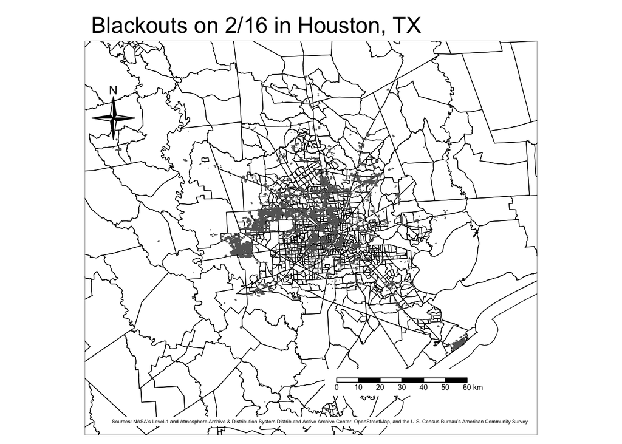

```r
tm_shape(hispanic_nad83, bbox = (st_bbox(roi))) +
  tm_borders("black", lwd = .7) +
tm_shape(blkout_buildings) +
  tm_polygons() +
  tm_scale_bar(position = c(.55, .1), bg.color = "white") +
  tm_compass(type = "4star", position = c(0, .75), size = 3) +
  tm_layout(main.title = "Blackouts on 2/16 in Houston, TX",
            frame.lwd = .5) +
  tm_credits("Sources: NASA’s Level-1 and Atmosphere Archive & Distribution System Distributed Active Archive Center, OpenStreetMap, and the U.S. Census Bureau’s American Community Survey", size = 3, align = "center", bg.color = "white")
```

### **Figure 1.** Areas of metropolitan Houston that experienced power outages as a result of severe winter storms in Feburary 2021. Gray areas indicate places that experienced blackouts.

## Map of Populations of Hispanic and Latino by Origin

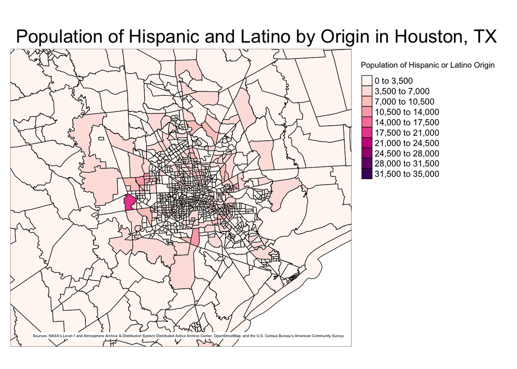

```r
# Create static map in tmap of people who identify as Hispanic/Latino
tmap::tmap_mode(mode = "plot") +
tm_shape(hispanic_nad83, bbox = (st_bbox(roi))) +
  tm_borders("black", lwd = .7) +
  tm_fill(col = "B03002e12", textNA = 0, colorNA = "gray", breaks = seq(from = 0, to = 35000, by = 3500),
          palette = "RdPu", n = 10, title = "Population of Hispanic or Latino Origin") +
  tm_legend(legend.outside = TRUE, legend.outside.position = "right") +
  tm_layout(main.title = "Population of Hispanic and Latino by Origin in Houston, TX",
            frame.lwd = .5) +
  tm_credits("Sources: NASA’s Level-1 and Atmosphere Archive & Distribution System Distributed Active Archive Center, OpenStreetMap, and the U.S. Census Bureau’s American Community Survey", size = 3, align = "center", bg.color = "white")
```

### **Figure 2.** Areas of metropolitan Houston that identify as Hispanic or Latino (pinks). Data retrived from the 2019 census tract data.

## Map of Blackouts and Hispanic/Latino Origin in Houston, TX

### Bonus question: Is there a socioeconomic metric that predicts being affected by the power outage?

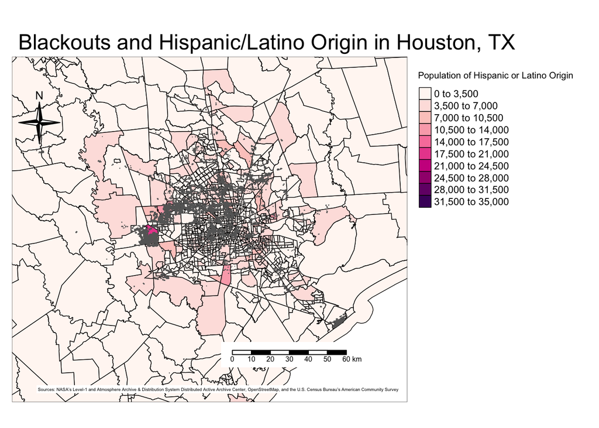

```r
# Create static map in tmap of blackouts and minority groups
tmap::tmap_mode(mode = "plot") +
tm_shape(hispanic_nad83, bbox = (st_bbox(roi))) +
  tm_borders("black", lwd = .7) +
  tm_fill(col = "B03002e12", textNA = 0, colorNA = "gray", breaks = seq(from = 0, to = 35000, by = 3500),
          palette = "RdPu", n = 10, title = "Population of Hispanic or Latino Origin") +

tm_shape(blkout_buildings_dis) +
  tm_polygons() +
  tm_borders("black", lwd = .01) +
  tm_fill("green", alpha = 0.1)+
  tm_scale_bar(position = c(.55, .1), bg.color = "white") +
  tm_compass(type = "4star", position = c(0, .75), size = 3) +
  tm_legend(legend.outside = TRUE, legend.outside.position = "right") +
  tm_layout(main.title = "Blackouts and Hispanic/Latino Origin in Houston, TX",
            frame.lwd = .5) +
  tm_credits("Sources: NASA’s Level-1 and Atmosphere Archive & Distribution System Distributed Active Archive Center, OpenStreetMap, and the U.S. Census Bureau’s American Community Survey", size = 3, align = "center", bg.color = "white")
```

### **Figure 3.** Areas of metropolitan Houston that experienced blackouts during the winter storms of February 2021 (dark gray) and the population of people that identify as Hispanic or Latino (pinks).

Visual examination indicates that areas with higher population of hispanic/latino have more blackout buildings. This is most evident in the western and northwestern census tracts that were hit the hardest.

## Summarize number of blacked out buildings by census tract

```r
tract_summary <- blackout_hispanic %>%
  group_by(TRACTCE,B03002e12) %>%
  summarize(count_by_tract =  n())
```

### Quick visualization to confirm visual trends in map

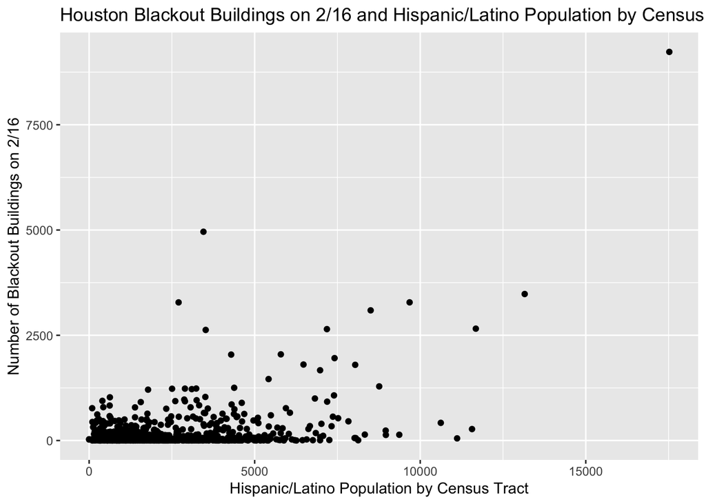

```r
ggplot(tract_summary, aes(x=B03002e12, y=count_by_tract)) +
  geom_point() +
  labs(title = "Houston Blackout Buildings on 2/16 and Hispanic/Latino Population by Census Tract")+
       xlab("Hispanic/Latino Population by Census Tract") +
       ylab("Number of Blackout Buildings on 2/16")
```

With the loosely positive correlation, the scatterplot is consistent with observations from the map. However, a more rigorous numerical analysis is recommended to confirm this. We would recommend redoing a similar analysis using population percentage rather than population numbers.